# Predicting Correct Exercise Form

DC

Sunday, October 25, 2015

# Introduction

Human activity recognition is an area of increasing interest for many people that want to monitor their daily activities. Monitoring behaviour patterns with human activity recognition devices such as the Jawbone UP, Nike FuelBan, and Fitbit are helping people closely monitor their exercise routines while improving their health.

# Data

References Data for this analysis was provided by Ugulino, W.; Cardador, D.; Vega, K.; Velloso, E.; Milidiu, R.; Fuks, H. Wearable Computing: Accelerometers’ Data Classification of Body Postures and Movements. Proceedings of 21st Brazilian Symposium on Artificial Intelligence. Advances in Artificial Intelligence - SBIA 2012. In: Lecture Notes in Computer Science. , pp. 52-61. Curitiba, PR: Springer Berlin / Heidelberg, 2012. ISBN 978-3-642-34458-9. DOI: 10.1007/978-3-642-34459-6_6.

# Aim of Study and Study Design

In this study, we will use the training data provided to develop a predictive model that predicts the method in which the participants performed the barbell lifts for the data in the test set. We will use the random forest model in this study, given that random forests are usually one of the two top performing algorithms in practice and are known to be very accurate.

We begin by partitioning the training data into a training set and a validation set using a 70:30 split. The training set is used to train and refine the model, where the rfcv function from the R randomForest package is used for cross validation and feature selection. The aim is to produce a model that has a maximum out of sample error rate of 3%.

The validation set will be used to validate the training model and estimate out of sample error once we have finished training the model.

Now that we have created the various datasets, we conduct feature selection on the training set using the rfcv function.

```r
crossval<- rfcv(train[,c(1:52)], train[,53], cv.fold=5, scale="log", step=0.75)
```

We plot the cross validation error rate by the number of predictors used in the model. As seen in the plot below, the error rate drop significantly as the number of predictors used in the model increases from 1 to 9. As the number of predictors increases beyond 9, the error rate levels off.

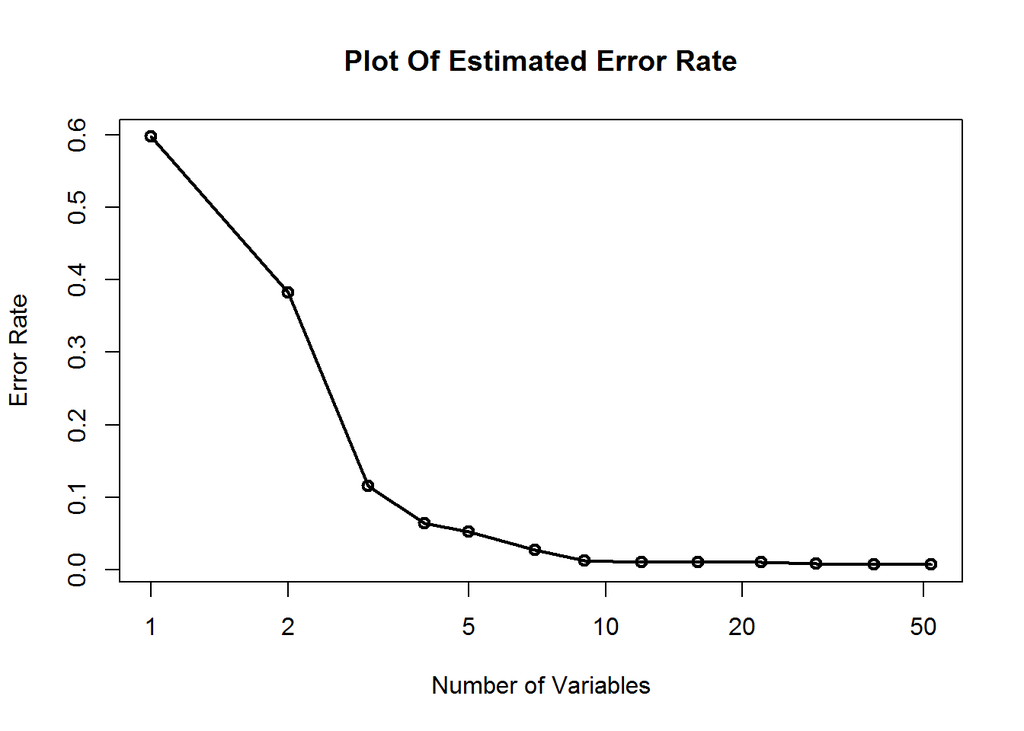

```r
with(crossval, plot(n.var, error.cv, log="x", type="o", lwd=2,
                    xlab="Number of Variables", ylab="Error Rate"))
title(main="Plot Of Estimated Error Rate")
```

We estimate an error rate for the model, which comes to about 1.2% when 9 variables are used. This is lower than our target of 3%.

```
##          52          39          29          22          16          12
## 0.006842833 0.007497998 0.008007571 0.009900269 0.010409842 0.010264250
##           9           7           5           4           3           2
## 0.012011356 0.026497780 0.052631579 0.063914974 0.115673000 0.382761884
##           1
## 0.597583170
```

We first create a random forest model using all the predictors, before we sieve out the 9 most critical predictors from it.

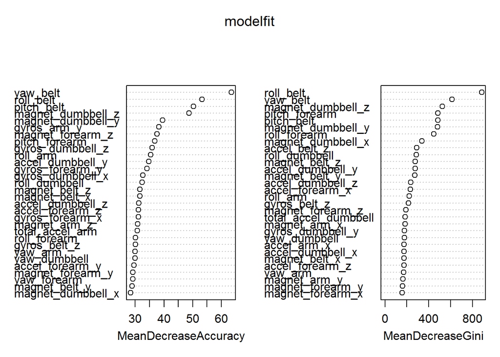

```r
modelfit <- randomForest(train[,c(1:52)], train$classe, importance=TRUE)

varImpPlot(modelfit)
```

```r
#Get the meanginidecrease of the predictors and extract the nine highest values
varimp <- sort(importance(modelfit)[,3], decreasing=TRUE)
varimp.top <- varimp[1:9]
top.pred <- names(varimp.top)
```

Now, we create a new random forest model using just these top 9 predictors.

```r
#Subset out the 9 predictors and classe predictor from training set
train.new <- train[ , top.pred]
train.new$classe <- train[,53]

model.new <- randomForest(train.new[,c(1:9)], train.new$classe)
```

We apply this new model to the validation set, and we evaluate the accuracy of the new model compared to the actual validation data.

```r
pred <- predict(model.new, vali)
```